# Data analysis for plates

This notebook predicts the off-target, heterozygous and homozygous samples for two different CRISPR experiments.

- Select values for global variables:
  - *PLOIDY*: indicates the ploidy of the cell line studied.
  - *EXCLUDED_SAMPLES*: substrings in the sample names that need to be excluded.
  - *EXPERIMENTAL_CONDITION*: triple plasmid CRISPR approach (PPP), plasmid-donor combined with RNPs strategy (PRNP).

```r
PLOIDY <- 3

EXCLUDED_SAMPLES <- c("U2OS", "Nup96", "NTC", "Comp")

#EXPERIMENTAL_CONDITION <- "PPP"
#EXPERIMENTAL_CONDITION <- "PRNP"
EXPERIMENTAL_CONDITION <- "PCRNP"
```

- Load libraries and functions.

```r
library(dplyr)
source("functions.R")
```

### Samples

- File paths for each experimental condition.
- Read and label data:

```r
fullGFP <- read.csv(fullGFP.filename, check.names=F, header=T, stringsAsFactors=F)
fullHDR <- read.csv(fullHDR.filename, check.names=F, header=T, stringsAsFactors=F)
fullGFP$Marker <- "GFP"
fullHDR$Marker <- "HDR"
```

- Select relevant columns (**Sample**, **Positives**, **Negatives**, **TargetType**, **Marker**, **T7**, **singleColony**, **imaging**) and bind GFP and HDR data.
- Label the **TargetType** properly:

```r
dataSAMPLES[dataSAMPLES$TargetType=="Unknown",]$TargetType <- "TARGET"
dataSAMPLES[dataSAMPLES$TargetType=="Reference",]$TargetType <- "REFERENCE"
```

- Compute **Ratio**, the Confidence Interval 95% (**MinCI95**, **MaxCI95**), relative error (**RelErr**) and theoretical standard deviation (**tSD**):

```r
dataSAMPLES$NegativeRate <- computeNegativeRate(dataSAMPLES)
dataSAMPLES <- computeConfidenceInterval(dataSAMPLES)
dataSAMPLES <- computeRelativeError(dataSAMPLES)
dataSAMPLES$tSD <- (dataSAMPLES$Ratio * dataSAMPLES$RelErr) / 1.96
```

> Number of samples = 80
- How many samples per TargetType/Marker?

```r
knitr::kable(table(dataSAMPLES[c("Marker","TargetType")]))
```

|  | TARGET |
| --- | --- |
| GFP | 40 |
| HDR | 40 |

- Remove samples with 0:

```r
dataSAMPLES <- dataSAMPLES[dataSAMPLES$Positives!=0,]
```

- How many samples per TargetType/Marker?

```r
knitr::kable(table(dataSAMPLES[c("Marker","TargetType")]))
```

|  | TARGET |
| --- | --- |
| GFP | 38 |
| HDR | 36 |

> Number of samples = 74
- Remove samples with no values in T7:

```r
dataSAMPLES <- dataSAMPLES[!is.na(dataSAMPLES$T7),]
```

- How many samples per TargetType/Marker?

```r
knitr::kable(table(dataSAMPLES[c("Marker","TargetType")]))
```

|  | TARGET |
| --- | --- |
| GFP | 38 |
| HDR | 36 |

> Number of samples = 74
- Remove samples with Relative Error > 20 %:

```r
dataSAMPLES <- dataSAMPLES[dataSAMPLES$RelErr < 0.2,]
```

```r
knitr::kable(table(dataSAMPLES[c("Marker","TargetType")]))
```

|  | TARGET |
| --- | --- |
| GFP | 27 |
| HDR | 25 |

### Reference distribution

- Read reference data.
- Label the **TargetType** of the reference sample.
- Remove samples with 0 positives:

```r
refSAMPLES <- refSAMPLES[refSAMPLES$Positives!=0,]
```

- Compute the **Negative Rate** of the reference sample:

```r
refSAMPLES$NegativeRate <- computeNegativeRate(refSAMPLES)
```

- Compute the **Ratio** and the **Confidence Interval** of the reference sample:

```r
refSAMPLES <- computeConfidenceInterval(refSAMPLES)
```

- Compute **Relative Error**:

```r
refSAMPLES <- computeRelativeError(refSAMPLES)
```

- Reference **means** and **SD** for both GFP and HDR dPCR assays:

```r
refSAMPLES_GFP_mean <- mean(refSAMPLES[refSAMPLES$Marker=="GFP",]$Ratio)
refSAMPLES_GFP_sd <- sd(refSAMPLES[refSAMPLES$Marker=="GFP",]$Ratio)

refSAMPLES_HDR_mean <- mean(refSAMPLES[refSAMPLES$Marker=="HDR",]$Ratio)
refSAMPLES_HDR_sd <- sd(refSAMPLES[refSAMPLES$Marker=="HDR",]$Ratio)
```

### Statistical Analysis

- Compute **Z-score**:

```r
dataSAMPLES.GFP <- dataSAMPLES[dataSAMPLES$Marker=="GFP",]
dataSAMPLES.HDR <- dataSAMPLES[dataSAMPLES$Marker=="HDR",]

dataSAMPLES.GFP$Zscore <- (dataSAMPLES.GFP$Ratio - refSAMPLES_GFP_mean) / refSAMPLES_GFP_sd
dataSAMPLES.HDR$Zscore <- (dataSAMPLES.HDR$Ratio - refSAMPLES_HDR_mean) / refSAMPLES_HDR_sd
```

- Corrected **p-values** for each sample (by marker) based on the Z-score.

The function `pnorm` provides the integral of the normal curve from `-Inf` to `Z`. Since we are running a two-tailed test, the result should be multiplied by 2. To ensure a negative Z-score, the negative of the absolute value of Z will be computed.

```r
dataSAMPLES.GFP$Pvalue <- 2 * pnorm(-abs(dataSAMPLES.GFP$Zscore))
dataSAMPLES.HDR$Pvalue <- 2 * pnorm(-abs(dataSAMPLES.HDR$Zscore))

dataSAMPLES.GFP$correctedPvalue <- p.adjust(dataSAMPLES.GFP$Pvalue, method="fdr")
dataSAMPLES.HDR$correctedPvalue <- p.adjust(dataSAMPLES.HDR$Pvalue, method="fdr")
```

- Selection of good sample candidates based on FDR > 0.1.

```r
dataSAMPLES.GFP$GoodSample <- dataSAMPLES.GFP$correctedPvalue >= 0.1
dataSAMPLES.HDR$GoodSample <- dataSAMPLES.HDR$correctedPvalue >= 0.1
```

- Combine GFP and HDR data:

```r
dataSAMPLES <- merge (dataSAMPLES.GFP, dataSAMPLES.HDR, by=c("Sample", "TargetType", "T7", "singleColony", "imaging"), suffixes = c(".GFP", ".HDR"))
```

- Keep only the samples with more than 10000 droplets (positives + negatives):

```r
dataSAMPLES <- dataSAMPLES %>% mutate (nDroplets_GFP = Positives.GFP+Negatives.GFP) %>%
                             mutate (nDroplets_HDR = Positives.HDR+Negatives.HDR) %>%
                             filter (nDroplets_GFP > 10000 & nDroplets_HDR > 10000)
```

#### Predict outcome

- *AGREEMENT* if Zeta <= 2
- *WARNING* if Zeta $\in$ (2,3]
- *DISAGREEMENT* if Zeta > 3

```r
dataSAMPLES$Zeta <- abs(dataSAMPLES$Ratio.GFP - dataSAMPLES$Ratio.HDR) /
                   sqrt(dataSAMPLES$tSD.GFP^2 + dataSAMPLES$tSD.HDR^2)

dataSAMPLES <- mutate(dataSAMPLES, prediction = ifelse(Zeta <= 2, "AGREEMENT",
                                              ifelse ((Zeta > 2 & Zeta <= 3), "WARNING", "DISAGREEMENT")))
```

- Potential off-targets (**singleColony** is 1 when the sample is accepted):

```r
offtargetSamples <- dataSAMPLES %>% filter(prediction == "DISAGREEMENT" & (Ratio.GFP > Ratio.HDR) & (dataSAMPLES$singleColony == 1))
```

- Potential heterozygous:

```r
heteroSamples <- dataSAMPLES %>% filter(prediction == "AGREEMENT" & GoodSample.GFP == FALSE & GoodSample.HDR == FALSE & dataSAMPLES$singleColony == 1)
```

- Potential homozygous:

```r
homoSamples <- dataSAMPLES %>% filter(prediction == "AGREEMENT" & GoodSample.GFP == TRUE & GoodSample.HDR == TRUE & dataSAMPLES$singleColony == 1)
```

- Unclassified (excluded):

```r
classifiedSamples <- rbind (offtargetSamples, heteroSamples, homoSamples)
excludedSamples <- dataSAMPLES %>% filter(!Sample %in% classifiedSamples$Sample) %>% select(Sample, Ratio.GFP, Ratio.HDR, GoodSample.GFP, GoodSample.HDR, prediction, T7, singleColony)
```

> 20 samples classified and 5 excluded.

#### Pie chart of off-targets, heterozygous and homozygous clones

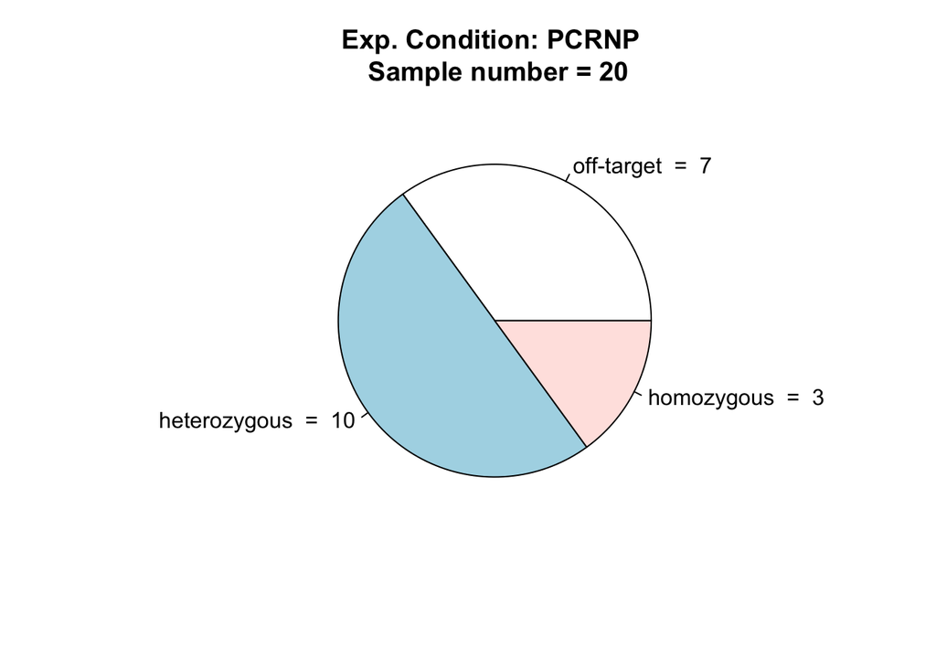

```r
pie_values <- c(nrow(offtargetSamples), nrow(heteroSamples), nrow(homoSamples))
sampleSize <- sum(pie_values)

pie_labels <- paste(c("off-target", "heterozygous", "homozygous"), " = " , pie_values)
pie(pie_values, labels=pie_labels, main=paste("Exp. Condition:",EXPERIMENTAL_CONDITION, "\n", "Sample number =", sampleSize))
```